# Malaria immunisation across Africa

Estimating the costs of administration/implementation (a work in progress)

Elisa Sicuri and Joe Brew

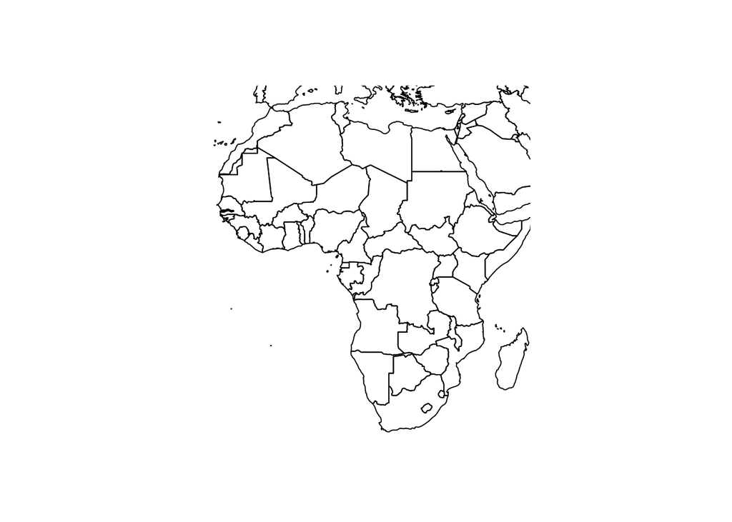

# Introduction

This document provides a basic overview of the work in progress that is the GSK malaria immunisation costing estimation. This project is being carried out under the direction of Dr. Elisa Sicuri. Its purpose is to provide country-specific estimates for the non-vaccine costs of implementing large-scale malaria immunisation across sub-saharan Africa.

# Data collection

Given that the a truly large-scale malaria vaccination campaign has *never* taken place, this study aims to *estimate* malaria immunisation unit costs indirectly by gathering data on the costs of other vaccination campaigns over the last two decades.

## Search strategy

For the purposes of both transparency and future reproducibility, we use a standard and automated search strategy. Our time frame of interest is 2000 to present day (June, 2016). Our search query is ‘((vaccine) OR (vaccination) OR (immunization)) AND (cost) AND (africa)’. The code for retrieving the papers and abstracts from PubMed (in the R programming language) is available [here](https://github.com/joebrew/gsk/blob/master/search_pubmed.R).

The initial query returned 985 results. We read the abstracts of all 985 papers, and eliminated more than 850 due to any of the following reasons:

- Geographic incompatibility (outside of sub-saharan Africa)
- Temporal incompatibility (outside of the time range in question)
- Subject matter irrelevance (non-human or animal vaccines, non-vaccines, opinion pieces, etc.)
- Lack of quantitative costing information
- Lack of cost itemization

All 985 “original” papers, prior to manual exclusion, can be obtained (here)[https://github.com/joebrew/gsk/blob/master/pubmed_results.csv?raw=true].

## Selected studies

|  | Title | Year | Affiliation | All authors | Url |
| --- | --- | --- | --- | --- | --- |
| 1 | Syndrome packets and health worker training improve sexually transmitted disease case management in rural South Africa: randomized controlled trial. | 2000 | South African Medical Research Council (Division of HIV Prevention and Vaccine Research) 1, Mtubatuba. harrisoa@mrc.ac.za | A Harrison, S A Karim, K Floyd, C Lombard, M Lurie, N Ntuli, D Wilkinson | http://www.ncbi.nlm.nih.gov/pubmed/?term=11125896 |
| 2 | The cost of integrating hepatitis B virus vaccine into national immunization programmes: a case study from Addis Ababa. | 2000 | Department of Biological Sciences, University of Warwick, Coventry, UK. jedmunds@phls.nhs.uk | W Edmunds, A Dejene, Y Mekonnen, M Haile, W Alemnu, D Nokes | http://www.ncbi.nlm.nih.gov/pubmed/?term=11124244 |
| 3 | The evidence base on the cost-effectiveness of malaria control measures in Africa. | 2000 | Department of Public Health and Policy, London School of Hygiene and Tropical Medicine, UK. c.goodman@lshtm.ac.uk | C A Goodman, A J Mills | http://www.ncbi.nlm.nih.gov/pubmed/?term=10787646 |
| 4 | Cost-effectiveness of iron supplementation and malaria chemoprophylaxis in the prevention of anaemia and malaria among Tanzanian infants. | 2000 | Epidemiology and Biostatistics Unit, Hospital Clinic, Barcelona, Spain. alonso@medicina.ub.es | M Alonzo González, C Menéndez, F Font, E Kahigwa, J Kimario, H Mshinda, M Tanner, X Bosch-Capblanch, P L Alonso | http://www.ncbi.nlm.nih.gov/pubmed/?term=10686744 |
| 5 | [Cost of tetanus toxoid injection using a jet-injector (Imule) in collective immunization in Senegal: comparison with injection using a syringe and resterilizable needle]. | 2000 | Association aide Médecine Préventive (AMP), 28, rue du Dr-Roux, 75724 Paris Cedex 15, France. | M Schlumberger, I P Châtelet, H Lafarge, A Genêt, A B Gaye, A Monnereau, C Sanou, L Diawara, Y Gueye, J Lang | http://www.ncbi.nlm.nih.gov/pubmed/?term=10657777 |
| 6 | A proposed vitamin A supplementation programme for South Africa--design, coverage and cost. | 2001 | Child Health Unit, Department of Paediatrics and Child Health, University of Cape Town. | R Saitowitz, M Hendricks, J Fiedler, I le Roux, G Hussey, B Makan | http://www.ncbi.nlm.nih.gov/pubmed/?term=11680325 |
| 7 | Comparison of cost-effectiveness of preventive and reactive mass immunization campaigns against meningococcal meningitis in West Africa: a theoretical modeling analysis. | 2001 | Association pour l'Aide à la Médecine Préventive, 28 rue du Docteur Roux, 75724 Cedex 15, Paris, France. iparent@compuserve.com | I Parent du Châtelet, B D Gessner, A da Silva | http://www.ncbi.nlm.nih.gov/pubmed/?term=11348706 |
| 8 | Model-based estimates of risks of disease transmission and economic costs of seven injection devices in sub-Saharan Africa. | 2002 | National Immunization Program, Centers for Disease Control and Prevention, Atlanta, GA, USA. dce3@cdc.gov | Donatus U Ekwueme, Bruce G Weniger, Robert T Chen | http://www.ncbi.nlm.nih.gov/pubmed/?term=12481207 |
| 9 | Economic analyses of rubella and rubella vaccines: a global review. | 2002 | Task Force for Child Survival and Development, Decatur, GA 30030, USA. Ahinman@taskforce.org | Alan R Hinman, Beryl Irons, Merle Lewis, Kami Kandola | http://www.ncbi.nlm.nih.gov/pubmed/?term=12075361 |
| 10 | [Vaccination against viral hepatitis B for public health personnel: the case of the National Fund of Social Security]. | 2002 | Polyclinique El Khadra CNSS, Tunis, Tunisie. | N Saadallah, N Jaoua, A Ben Hamida, T Najjar, B Zouari | http://www.ncbi.nlm.nih.gov/pubmed/?term=11892442 |

[output cut: 123 more lines]

# Data analysis

## Itemization and data extraction

Having finished selection, we extract from each study the itemized costs of immunization, excluding the actual purchase of vaccine. The categories are:

- Administration
- Transportation
- Wastage
- Equipment
- Training
- Sensitisation
- Human resources

In some cases, only total/overall costs were available, in which case we used average values from other studies to interpolate item-specific costs.

Following itemization, we standardize all costs from local currencies and past values to the equivalent of 2016 United States Dollars.

## Modeling

In addition to the country- and region-specific implementation costs estimation, we will estimate the effect of macroeconomic factors (GDP per capita, physician density, general indicators of health and health sector performance) on costs. Where significant, we will include these determinants into a final statistical model, which will be generalizable for future cost estimation, as well as more granular cost estimates.